## EDA Case Study: Business Analytics for FMCG company

### Background: A large FMCG company has presence in PAN India. The company owns variety of brands in 3 business lines-Ice-Creams, Cakes-Biscuits and Chocolates.

### The company has transaction data of its dealers (customers in this case) over the years. In this case study, data is available for the year 2014. In addition to the transaction data, the net promoter scores (NPS) are recorded for a sample of customers using online survey.

### The business objective is to analyze the data and generate insights for customer behavior.

#### Import NSVDATA,CUST_PROFILE and NPSDATA in R

```r
nsv<-read.csv("NSVDATA.csv",header=T)
cust<-read.csv("CUST_PROFILE.csv",header=T)
nps<-read.csv("NPSDATA.csv",header=T)
```

#### Data Description

| Column name | Column desciption |
| --- | --- |
| CUSTID | Customer Identification Code |
| MONTH | Month of transaction |
| YEAR | Year of transaction |
| BUSINESS | Type of Business |
| NSV | Net Sales Value for the transaction |
| REGION | Region of customer |
| NPS | Net Promoter Score of customer |

#### Apply functions like head,dim,str,summary to understand data characteristics.

```r
dim(nps)
```

```
[1] 107   2
```

```r
str(nps)
```

```
'data.frame':   107 obs. of  2 variables:
 $ CUSTID: int  22929 12089 19120 10155 13085 14784 17714 19735 23779 10477 ...
 $ NPS   : int  6 5 6 8 9 4 5 6 2 9 ...
```

```r
head(nps)
```

```
  CUSTID NPS
1  22929   6
2  12089   5
3  19120   6
4  10155   8
5  13085   9
6  14784   4
```

```r
dim(nsv)
```

```
[1] 41425     5
```

```r
str(nsv)
```

```
'data.frame':   41425 obs. of  5 variables:
 $ CUSTID  : int  10000 10000 10000 10000 10001 10001 10001 10001 10004 10004 ...
 $ MONTH   : int  5 8 10 10 3 6 7 12 8 10 ...
 $ YEAR    : int  2014 2014 2014 2014 2014 2014 2014 2014 2014 2014 ...
 $ BUSINESS: chr  "CAKES" "ICECREAM" "CAKES" "CHOCOLATES" ...
 $ NSV     : int  21793 29630 1530 7155 39256 20355 6122 2902 34218 28881 ...
```

```r
head(nsv)
```

```
  CUSTID MONTH YEAR   BUSINESS   NSV
1  10000     5 2014      CAKES 21793
2  10000     8 2014   ICECREAM 29630
3  10000    10 2014      CAKES  1530
4  10000    10 2014 CHOCOLATES  7155
5  10001     3 2014 CHOCOLATES 39256
6  10001     6 2014   ICECREAM 20355
```

```r
dim(cust)
```

```
[1] 15001     2
```

```r
str(cust)
```

```
'data.frame':   15001 obs. of  2 variables:
 $ CUSTID: int  10000 10001 10002 10003 10004 10005 10006 10007 10008 10009 ...
 $ REGION: chr  "North" "South" "West" "South" ...
```

```r
head(cust)
```

```
  CUSTID REGION
1  10000  North
2  10001  South
3  10002   West
4  10003  South
5  10004   East
6  10005   West
```

#### Objective: Show Number of Unique Customers

#### Number of unique customers in each of these three datasets

```r
length(unique(nsv$CUSTID))
```

```
[1] 14077
```

```r
length(unique(cust$CUSTID))
```

```
[1] 15001
```

```r
length(unique(nps$CUSTID))
```

```
[1] 107
```

#### Objective: Find top 10 and bottom 10 performing customers

#### Aggregate sales in 2014 for each customer

```r
agg_sales<-aggregate(NSV~CUSTID,data=nsv,FUN=sum)
head(agg_sales)
```

```
  CUSTID   NSV
1  10000 60108
2  10001 68635
3  10004 69882
4  10005  9180
5  10006 93386
6  10008 33519
```

#### Sort in descending order and display top 10 performers

```r
smstop<-head(agg_sales[order(-agg_sales$NSV),],10)
smstop
```

```
      CUSTID    NSV
9326   19921 280634
890    10953 271115
11449  22185 264753
1295   11385 260205
6677   17096 254817
2081   12216 253842
10348  21012 253635
853    10915 247899
1997   12130 246448
398    10427 243566
```

#### Sort in ascending order and display bottom 10 performers

```r
smsbottom<-head(agg_sales[order(agg_sales$NSV),],10)
smsbottom
```

```
      CUSTID NSV
10784  21477   7
5197   15516  11
10183  20831  11
12415  23221  20
8217   18732  32
7090   17538  33
10187  20836  42
668    10716  61
9422   20023  69
5582   15925  74
```

#### Objective: Show how the top 100 dealers are distributed across Regions

#### Merge agg_sales data with CUST_PROFILE data

```r
mapped<-merge(agg_sales,cust,by="CUSTID")
head(mapped)
```

```
  CUSTID   NSV REGION
1  10000 60108  North
2  10001 68635  South
3  10004 69882   East
4  10005  9180   West
5  10006 93386   West
6  10008 33519   East
```

#### Sort in descending order and store top 100 performers

```r
top100<-head(mapped[order(-mapped$NSV),],100)
head(top100)
```

```
      CUSTID    NSV REGION
9326   19921 280634  North
890    10953 271115  South
11449  22185 264753  North
1295   11385 260205  North
6677   17096 254817  North
2081   12216 253842   West
```

#### Frequency distribution of top 100 performers

```r
table(top100$REGION)
```

```
 East North South  West
   23    26    28    23
```

#### Top 100 performers are uniformly distributed across regions

#### Objective: Check performance of customers in each region using measures of central tendency and variation(min,max,mean,median, coefficient of variation)

#### Create your own function to calculate mean, median, maximum, minimum and coefficient of variation

```r
f<-function(x)c(n=length(x),mean=mean(x),median=median(x),
                max=max(x),min=min(x),cv=(sd(x)/mean(x)*100))
```

#### Apply your function on data mapped

```r
region_per<-aggregate(NSV~REGION,data=mapped,FUN=f)
region_per
```

```
  REGION        NSV.n     NSV.mean   NSV.median      NSV.max      NSV.min
1   East   3447.00000  57246.83348  49298.00000 243566.00000     11.00000
2  North   3576.00000  58379.91303  50777.50000 280634.00000     32.00000
3  South   3475.00000  58766.42302  51672.00000 271115.00000     20.00000
4   West   3579.00000  59079.61945  52133.00000 253842.00000      7.00000
        NSV.cv
1     71.35873
2     70.85262
3     70.23593
4     69.01667
```

#### Using dplyr to aggregate

```r
library(dplyr)
region_per2<-mapped %>% group_by(REGION) %>% summarise(n=length(NSV),mean=mean(NSV),median=median(NSV),                                     max=max(NSV),min=min(NSV),cv=(sd(NSV)/mean(NSV)*100)) %>%as.data.frame()
region_per2
```

```
  REGION    n     mean  median    max min       cv
1   East 3447 57246.83 49298.0 243566  11 71.35873
2  North 3576 58379.91 50777.5 280634  32 70.85262
3  South 3475 58766.42 51672.0 271115  20 70.23593
4   West 3579 59079.62 52133.0 253842   7 69.01667
```

#### Objective: Visually depict the dealers performance across Regions(Mean sales for each region)

#### Aggregate NSV for each region

```r
region_sales<-aggregate(NSV~REGION,data=mapped,FUN=mean)
names(region_sales)
```

```
[1] "REGION" "NSV"
```

#### Simple bar graph using ggplot2

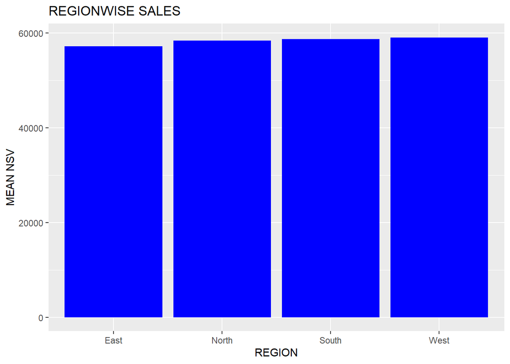

```r
library(ggplot2)
ggplot(region_sales,aes(x=REGION,y=NSV))+
  geom_bar(stat="identity",fill="blue")+
  labs(x="REGION",y="MEAN NSV",title="REGIONWISE SALES")
```

#### Objective: Observe the activity of dealers across Months

#### Create function to calculate unique observations

```r
f1<-function(x)(length(unique(x)))
```

#### Count number of unique months of transaction for each customers

```r
freq<-aggregate(MONTH~CUSTID,data=nsv,FUN=f1)
table(freq$MONTH)
```

```
   1    2    3    4    5    6    7    8
2963 4181 3637 2082  851  288   64   11
```

#### Most of the customers have transacted in 1-4 months in a year with 2 being highest buying frequency

#### Objective: Get insight on contribution to total sales by each Business Type (Line of Business)

#### Aggregate NSV by BUSINESS

```r
LoB<-aggregate(NSV~BUSINESS,data=nsv,FUN=sum)
Tot<-sum(LoB$NSV)
LoB$CONTRI<-(LoB$NSV/Tot)*100
LoB
```

```
    BUSINESS       NSV   CONTRI
1      CAKES 324099472 39.43988
2 CHOCOLATES 332482115 40.45997
3   ICECREAM 165174095 20.10015
```

#### Ice Creams contribution is 20% where as cakes and chocolates contribution is 40% each

#### Pie chart for percentage contribution

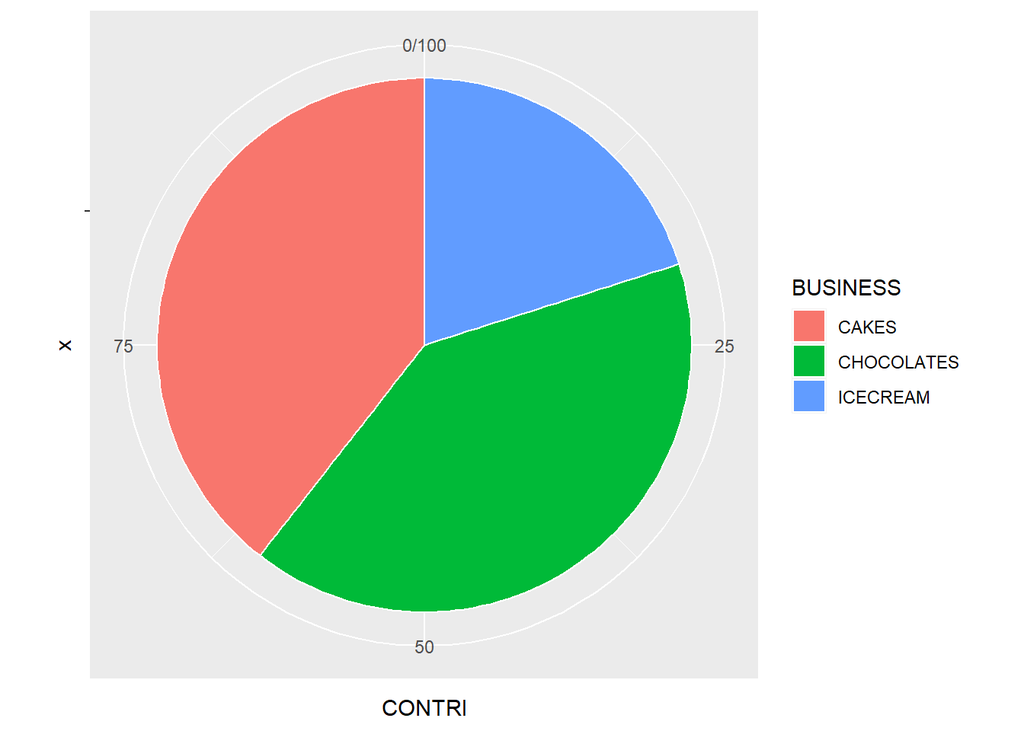

```r
ggplot(LoB, aes(x="", y=CONTRI, fill=BUSINESS)) +
  geom_bar(stat="identity", width=1, color="white") +
  coord_polar("y", start=0)
```

#### Objective: Observe the sales trend across the Year(Month wise Trendline)

#### Aggregate NSV for each month

```r
Month<-aggregate(NSV~MONTH,data=nsv,FUN=sum)
```

#### Month wise Trendline

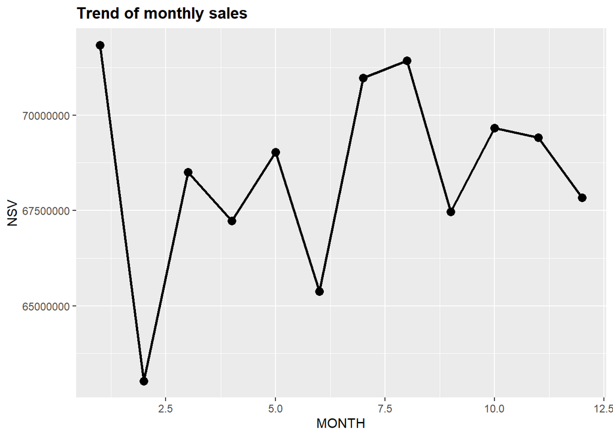

```r
ggplot(Month, aes(x=MONTH, y=NSV))+
  geom_line(size=1)+
  geom_point(size=3)+
  labs(y="NSV", title="Trend of monthly sales")+
  theme(plot.title=element_text(face="bold"))
```

#### Objective: Understand Net Promoter Score in each region(Median NPS by Region)

#### Check nps data

```r
head(nps)
```

```
  CUSTID NPS
1  22929   6
2  12089   5
3  19120   6
4  10155   8
5  13085   9
6  14784   4
```

#### Merge ‘nps’ with ‘cust’

```r
nps_reg<-merge(nps,cust,by="CUSTID",)
median_nps<-aggregate(NPS~REGION,data=nps_reg,FUN=median)
median_nps
```

```
  REGION NPS
1   East   6
2  North   6
3  South   6
4   West   7
```

#### Median Net Promoter Score is similar across regions

#### Objective: Understand percentage of detractors and promoters in each region

#### Create buckets for NPS using cut function

```r
nps_reg$type<-cut(nps_reg$NPS,breaks=c(-1,6,8,10),
                  labels=c("Detractor","Passive","Promoter"))
```

#### Crosstable of region and type using gmodels

```r
library(gmodels)
CrossTable(nps_reg$REGION,nps_reg$type)
```

```
   Cell Contents
|-------------------------|
|                       N |
| Chi-square contribution |
|           N / Row Total |
|           N / Col Total |
|         N / Table Total |
|-------------------------|


Total Observations in Table:  107


               | nps_reg$type
nps_reg$REGION | Detractor |   Passive |  Promoter | Row Total |
---------------|-----------|-----------|-----------|-----------|
          East |        13 |         5 |         2 |        20 |
               |     0.353 |     0.623 |     0.009 |           |
               |     0.650 |     0.250 |     0.100 |     0.187 |
               |     0.220 |     0.132 |     0.200 |           |
               |     0.121 |     0.047 |     0.019 |           |
---------------|-----------|-----------|-----------|-----------|
         North |        13 |         8 |         3 |        24 |
               |     0.004 |     0.032 |     0.255 |           |
               |     0.542 |     0.333 |     0.125 |     0.224 |
               |     0.220 |     0.211 |     0.300 |           |
               |     0.121 |     0.075 |     0.028 |           |
---------------|-----------|-----------|-----------|-----------|
         South |        20 |        12 |         3 |        35 |
               |     0.025 |     0.015 |     0.022 |           |
               |     0.571 |     0.343 |     0.086 |     0.327 |
               |     0.339 |     0.316 |     0.300 |           |
               |     0.187 |     0.112 |     0.028 |           |
---------------|-----------|-----------|-----------|-----------|
          West |        13 |        13 |         2 |        28 |
               |     0.385 |     0.939 |     0.145 |           |
               |     0.464 |     0.464 |     0.071 |     0.262 |
               |     0.220 |     0.342 |     0.200 |           |
               |     0.121 |     0.121 |     0.019 |           |
---------------|-----------|-----------|-----------|-----------|
  Column Total |        59 |        38 |        10 |       107 |
               |     0.551 |     0.355 |     0.093 |           |
---------------|-----------|-----------|-----------|-----------|
```